# Project 1: Wrangling, Exploration, Visualization

#### Visualizing

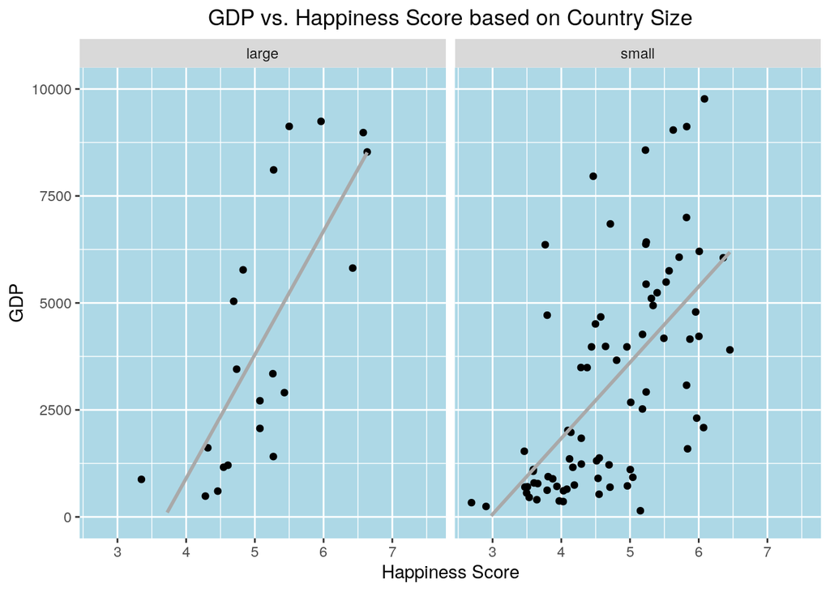

```r
finaljoined %>% ggplot(aes(Happiness.Score, GDP)) + geom_point() +
    geom_smooth(color = "darkgray", method = "lm", se = F) +
    facet_wrap(~Country.size) + ggtitle("GDP vs. Happiness Score based on Country Size") +
    scale_y_continuous(limits = c(0, 10000)) + labs(x = "Happiness Score") +
    theme(plot.title = element_text(hjust = 0.5), panel.background = element_rect(fill = "lightblue",
        colour = "lightblue", size = 0.5, linetype = "solid"))
```

The plot above shows the relationship between the happiness score and GDP of the countries in the data set. This plot is faceted by the size of the country (small and large). As seen by the plot, there appears to be a positive relationship between GDP and the happiness score. As the GDP of a country increases, they have increasingly higher happiness scores. This relationship is present in both small and large countries, and there does not appear to be a significant difference in the relationship between GDP and happiness scores between small and large countries.

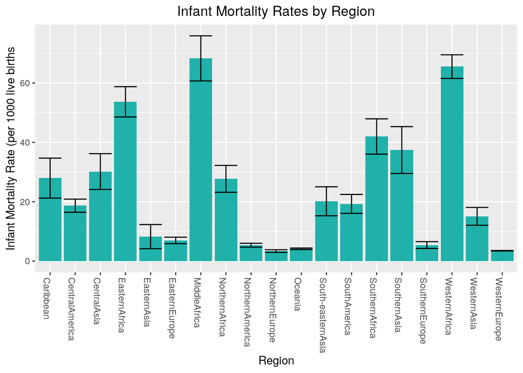

```r
finaljoined %>% ggplot(aes(Region, infmort)) + geom_bar(stat = "summary",
    fun = mean, fill = "lightseagreen") + geom_errorbar(stat = "summary") +
    theme(axis.text.x = element_text(angle = -90, hjust = 0)) +
    labs(title = "Infant Mortality Rates by Region", x = "Region",
        y = "Infant Mortality Rate (per 1000 live births") +
    theme(plot.title = element_text(hjust = 0.5))
```

The barplot above shows the average infant mortality rates for each region in the joined data set. As observed in the plot, the regions with the highest infant mortality rate are Middle Africa, Western Africa, and Eastern Africa. From the wrangling section, we learned that Middle Africa also had the lowest mean happiness score. The regions with the lowest infant mortality rate are Western Europe, Northern Europe, and Oceania. Western Europe and Oceania have some of the highest mean happiness scores. From these results, it can be inferred that there is an inverse relationship with happiness scores and infant mortality rates. The higher the infant mortality rate tends to be for a region, the lower the mean happiness score tends to be. It can also be observed that European regions tend to have the lowest infant mortality rates, and African regions tend to have the highest infant mortality rates.

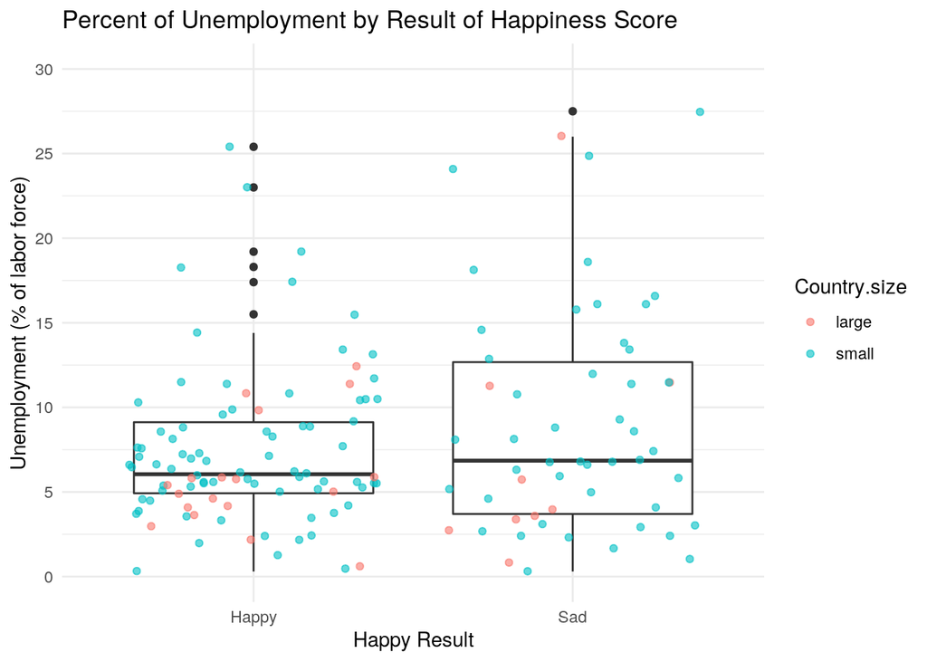

```r
finaljoined %>% ggplot(aes(x = HappyResult, y = unemployement)) +
    geom_boxplot() + geom_jitter(alpha = 0.6, aes(color = Country.size)) +
    scale_y_continuous(name = "Unemployment (% of labor force)",
        breaks = c(0, 5, 10, 15, 20, 25, 30), limits = c(0, 30)) +
    labs(x = "Happy Result") + ggtitle("Percent of Unemployment by Result of Happiness Score") +
    theme(plot.title = element_text(hjust = 0.5)) + theme_minimal()
```

This last plot shows the distribution of unemployment (by %), and it separates countries by if they’re classified as “Happy” or “Sad”. As seen in the graph, it seems that sad countries have slightly higher rates of unemployment, although the relationship is not that strong, since there is a lot of overall among the boxplots. The mean unemployment rate for sad countries is slightly above that of happy countries, but the upper quartile is clearly higher in the sad countries. Additionally, there are more outliers of countries that are classified as happy but have higher unemployment rates, but there is only one outlier for sad countries. From the graph it can also be seen that there is not any difference between small and large countries. They are distributed uniformly across unemployment rates and country size.

#### Concluding Remarks

After joining both data sets, computing summary statistics, and creating plots for various variables, we have seen that some of the predicted observations are true. Happiness scores do tend to be positively related to the GDP of each country, and it seems to be inversely related to unemployment rates (as unemployment increases, countries tend to be less happy). The effect of these variables on happiness does not have a different effect on small versus large countries, and the happiest countries in 2017 are mostly in Europe and the Americas.